# Genome-wide methylation analysis report

- study: ePTB_boys_noNAbetas_noEosinos_allCells_rlm_adj
- author: DJQ
- date: 19 November, 2025

## Parameters

```
## $sig.threshold
## [1] 5.389319e-08
##
## $max.plots
## [1] 10
##
## $qq.inflation.method
## [1] "median"
##
## $practical.threshold
## [1] 1.302106e-43
```

## Sample characteristics

For continuous or ordinal variables, the “mean” column provides the mean and the “sd/%” column the standard deviation of the variable. For categorical variables, the “mean” column provides the number of samples with the given “value” and the “sd/%” column the percentage of samples with the given “value”.

| variable | value | mean | sd.. |
| --- | --- | --- | --- |
| eptb_binePTB case |  | 0.6043165 | 0.4907655 |
| A2age |  | 28.01439 | 6.824918 |
| gravidityprimiparous |  | 0.294964 | 0.4576759 |
| employedYes |  | 0.5395683 | 0.5002345 |
| prebmi |  | 25.41298 | 5.080006 |
| Epi |  | 0.9130965 | 0.1045969 |
| B |  | 0.01721973 | 0.01683903 |
| NK |  | 0.01729809 | 0.01528133 |
| CD4T |  | 0.008384625 | 0.007066733 |
| CD8T |  | 0.0001009013 | 0.000880905 |
| Mono |  | 0.01469393 | 0.01708545 |
| Neutro |  | 0.02680696 | 0.05172206 |
| sv1 |  | 8.606147e-18 | 0.08512565 |
| sv2 |  | -8.418654e-19 | 0.08512565 |
| sv3 |  | 4.808198e-17 | 0.08512565 |
| sv4 |  | -3.874122e-17 | 0.08512565 |
| sv5 |  | 1.178139e-16 | 0.08512565 |
| sv6 |  | -3.737236e-17 | 0.08512565 |
| sv7 |  | -3.416124e-17 | 0.08512565 |
| sv8 |  | 8.382287e-18 | 0.08512565 |
| sv9 |  | -6.781558e-17 | 0.08512565 |
| sv10 |  | 1.503928e-17 | 0.08512565 |

## Covariate associations

### Covariate A2age

statistics

| var1 | var2 | F | p-value | R | p-value |
| --- | --- | --- | --- | --- | --- |
| eptb_binePTB case | A2age | 2.331444 | 0.1290896 | 0.1108687 | 0.1938313 |

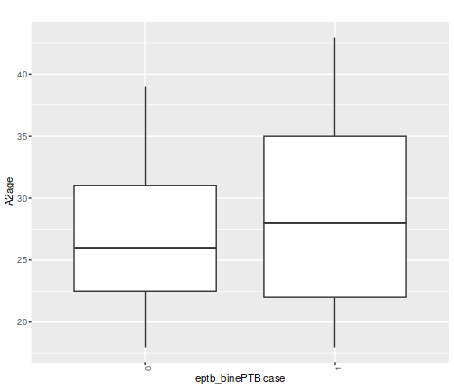

### Covariate gravidityprimiparous

statistics

| var1 | var2 | F | p-value | R | p-value |
| --- | --- | --- | --- | --- | --- |
| eptb_binePTB case | gravidityprimiparous | 0.0861369 | 0.7695911 | -0.0250667 | 0.7695911 |

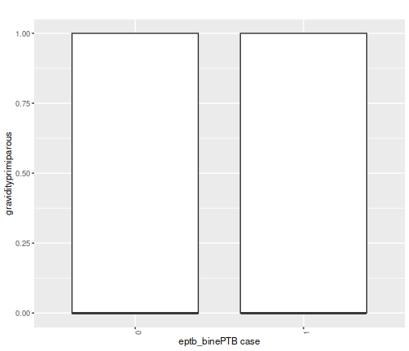

### Covariate employedYes

statistics

| var1 | var2 | F | p-value | R | p-value |
| --- | --- | --- | --- | --- | --- |
| eptb_binePTB case | employedYes | 0.3362124 | 0.5629761 | 0.0494782 | 0.5629761 |

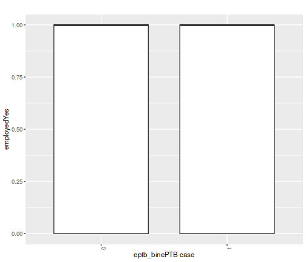

### Covariate prebmi

statistics

| var1 | var2 | F | p-value | R | p-value |
| --- | --- | --- | --- | --- | --- |
| eptb_binePTB case | prebmi | 0.1071376 | 0.7439263 | -0.0617839 | 0.4699662 |

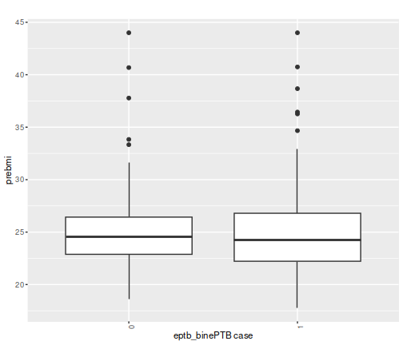

### Covariate Epi

statistics

| var1 | var2 | F | p-value | R | p-value |
| --- | --- | --- | --- | --- | --- |
| eptb_binePTB case | Epi | 4.35445 | 0.0387657 | 0.0003667 | 0.996582 |

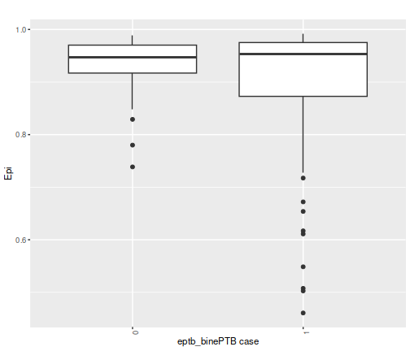

### Covariate B

statistics

| var1 | var2 | F | p-value | R | p-value |
| --- | --- | --- | --- | --- | --- |
| eptb_binePTB case | B | 4.195723 | 0.0424357 | 0.0142998 | 0.8673082 |

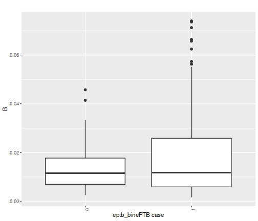

### Covariate NK

statistics

| var1 | var2 | F | p-value | R | p-value |
| --- | --- | --- | --- | --- | --- |
| eptb_binePTB case | NK | 2.205075 | 0.1398546 | -0.0142998 | 0.8673082 |

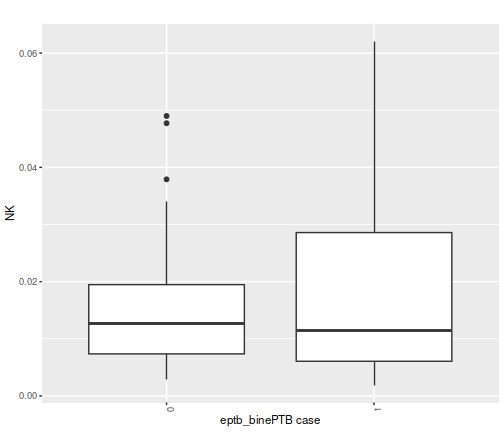

### Covariate CD4T

statistics

| var1 | var2 | F | p-value | R | p-value |
| --- | --- | --- | --- | --- | --- |
| eptb_binePTB case | CD4T | 2.382348 | 0.1250197 | 0.0113665 | 0.8943488 |

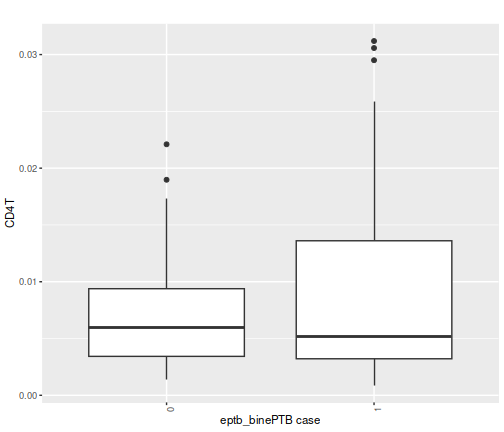

### Covariate CD8T

statistics

| var1 | var2 | F | p-value | R | p-value |
| --- | --- | --- | --- | --- | --- |
| eptb_binePTB case | CD8T | 1.074231 | 0.3018178 | 0.0203928 | 0.8116632 |

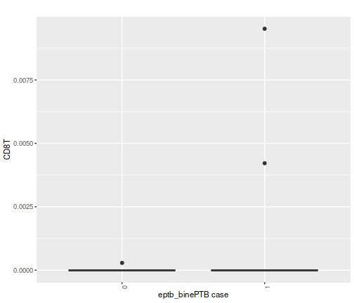

### Covariate Mono

statistics

| var1 | var2 | F | p-value | R | p-value |
| --- | --- | --- | --- | --- | --- |
| eptb_binePTB case | Mono | 3.708785 | 0.0561983 | -0.0025666 | 0.9760774 |

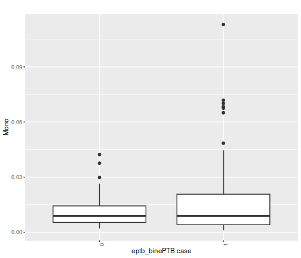

### Covariate Neutro

statistics

| var1 | var2 | F | p-value | R | p-value |
| --- | --- | --- | --- | --- | --- |
| eptb_binePTB case | Neutro | 5.882373 | 0.0165952 | 0.029333 | 0.7317629 |

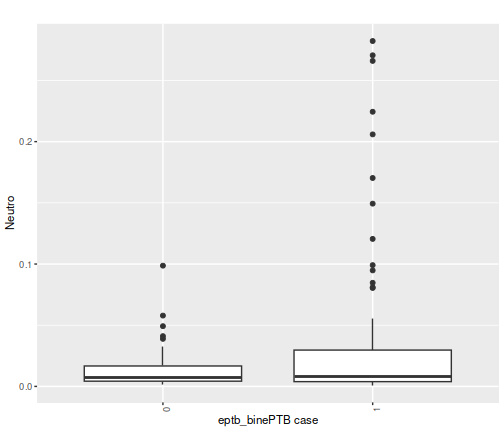

### Covariate sv1

statistics

| var1 | var2 | F | p-value | R | p-value |
| --- | --- | --- | --- | --- | --- |
| eptb_binePTB case | sv1 | 5.286782 | 0.0230002 | -0.0601326 | 0.4819389 |

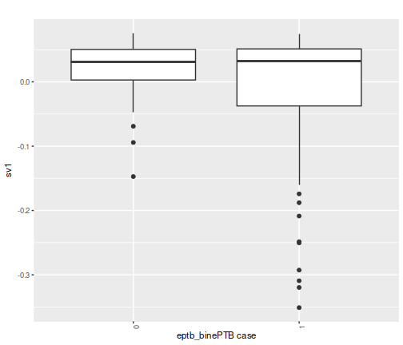

### Covariate sv2

statistics

| var1 | var2 | F | p-value | R | p-value |
| --- | --- | --- | --- | --- | --- |
| eptb_binePTB case | sv2 | 0.0521221 | 0.8197513 | -0.0318996 | 0.7093051 |

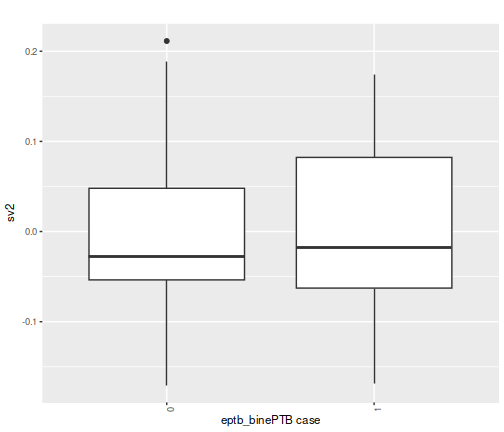

### Covariate sv3

statistics

| var1 | var2 | F | p-value | R | p-value |
| --- | --- | --- | --- | --- | --- |
| eptb_binePTB case | sv3 | 17.97572 | 4.09e-05 | 0.3376958 | 4.79e-05 |

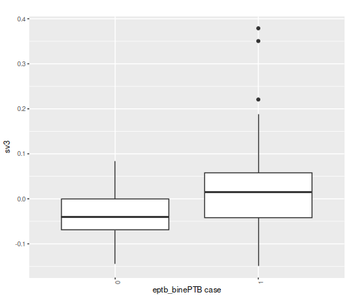

### Covariate sv4

statistics

| var1 | var2 | F | p-value | R | p-value |
| --- | --- | --- | --- | --- | --- |
| eptb_binePTB case | sv4 | 7.994833 | 0.0053949 | 0.2086308 | 0.013713 |

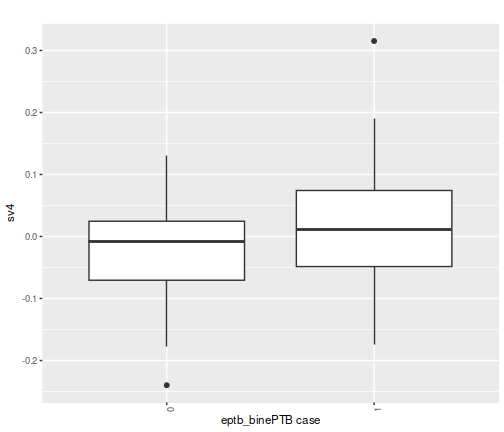

### Covariate sv5

statistics

| var1 | var2 | F | p-value | R | p-value |
| --- | --- | --- | --- | --- | --- |
| eptb_binePTB case | sv5 | 2.938958 | 0.0887278 | 0.1455649 | 0.0873017 |

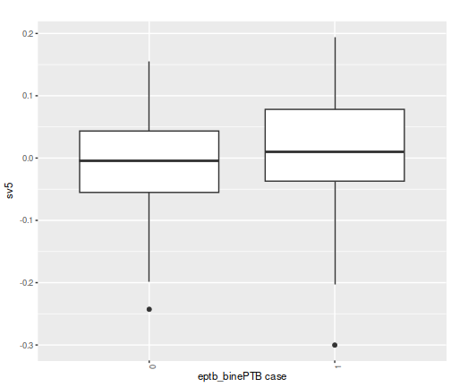

### Covariate sv6

statistics

| var1 | var2 | F | p-value | R | p-value |
| --- | --- | --- | --- | --- | --- |
| eptb_binePTB case | sv6 | 2.579067 | 0.110588 | -0.1202652 | 0.1584731 |

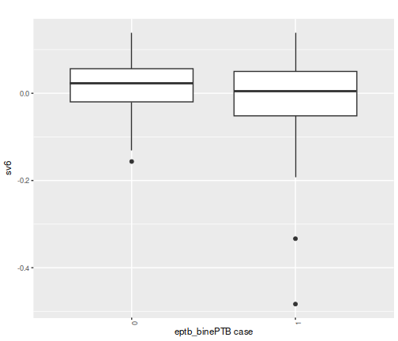

### Covariate sv7

statistics

| var1 | var2 | F | p-value | R | p-value |
| --- | --- | --- | --- | --- | --- |
| eptb_binePTB case | sv7 | 3.235424 | 0.0742632 | -0.1213652 | 0.1546725 |

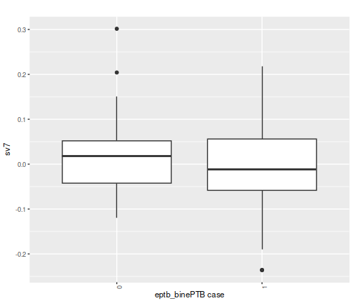

### Covariate sv8

statistics

| var1 | var2 | F | p-value | R | p-value |
| --- | --- | --- | --- | --- | --- |
| eptb_binePTB case | sv8 | 11.73264 | 0.0008107 | 0.3827953 | 3.3e-06 |

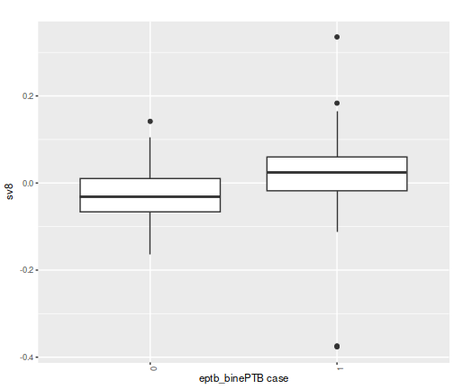

### Covariate sv9

statistics

| var1 | var2 | F | p-value | R | p-value |
| --- | --- | --- | --- | --- | --- |
| eptb_binePTB case | sv9 | 0.8387208 | 0.3613721 | 0.078099 | 0.3607925 |

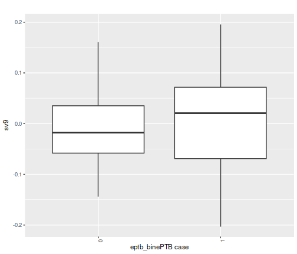

### Covariate sv10

statistics

| var1 | var2 | F | p-value | R | p-value |
| --- | --- | --- | --- | --- | --- |
| eptb_binePTB case | sv10 | 0.022414 | 0.8812113 | 0.0366662 | 0.6682662 |

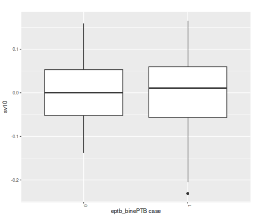

## QQ plots

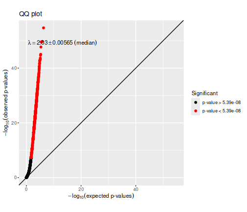

## Manhattan plots

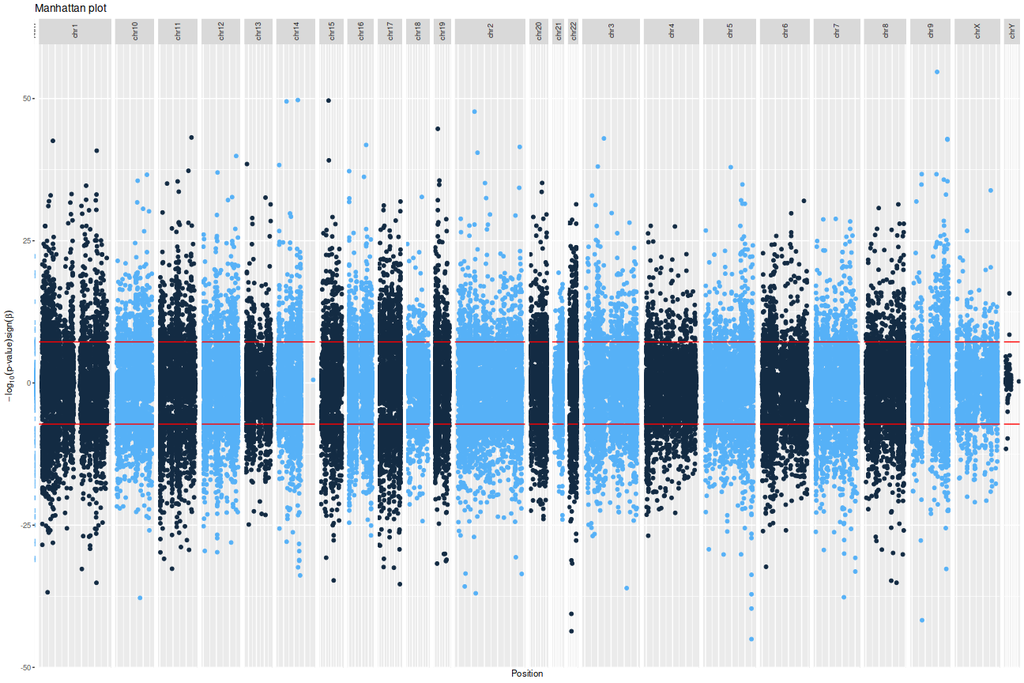

## Significant CpG sites

There were 17438 CpG sites with association p-values < 5.389319 × 10<sup>-8</sup>. These are listed in the file associations.csv.

Below are the 10 CpG sites with association p-values < 1.3021062 × 10<sup>-43</sup> in the regression model.

|  | chromosome | position | estimate | p.value | p.adjust |
| --- | --- | --- | --- | --- | --- |
| cg01714756 | chr14 | 94314063 | 0.1801969 | 0 | 0 |
| cg10157208 | chr19 | 13001635 | 0.1031569 | 0 | 0 |
| cg02458632 | chr2 | 62450946 | 0.1772730 | 0 | 0 |
| cg19034820 | chr22 | 28147187 | -0.1206528 | 0 | 0 |
| cg11343820 | chr5 | 174617516 | -0.1903923 | 0 | 0 |
| cg08224960 | chr9 | 95082818 | 0.1337939 | 0 | 0 |
| cg19489600 | chr14 | 51337991 | 0.1484301 | 0 | 0 |
| cg20383223 | chr15 | 51052020 | 0.1493361 | 0 | 0 |
| cg05103200 | chr3 | 72836974 | 0.1143418 | 0 | 0 |
| cg16986026 | chr11 | 120241281 | 0.1188449 | 0 | 0 |

Plots of these sites follow, one for each covariate set. “p[lm]” denotes the p-value obtained using a linear model and “p[beta]” the p-value obtained using beta regression.

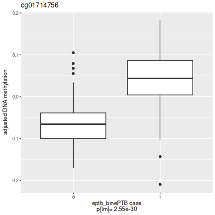

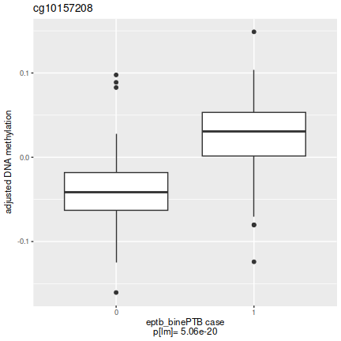

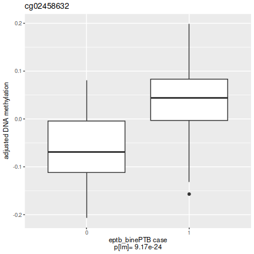

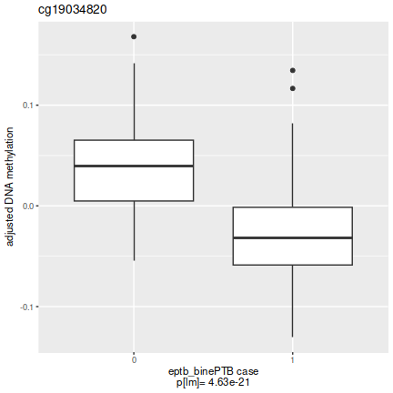

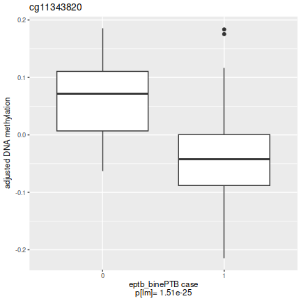

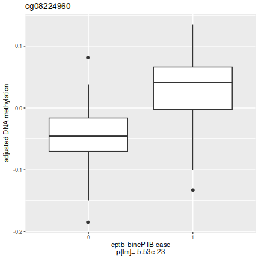

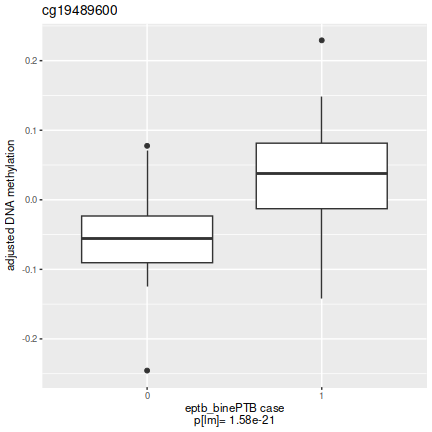

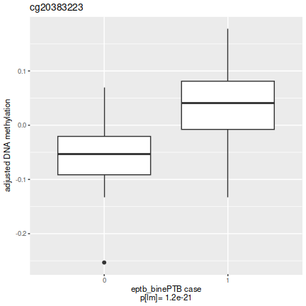

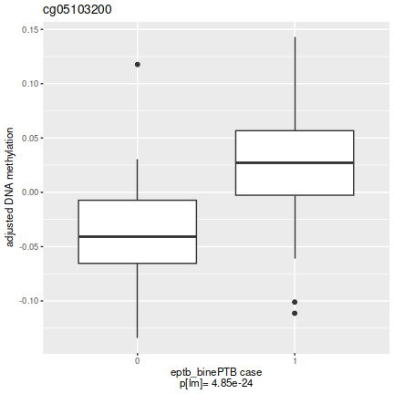

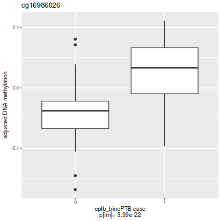

## Selected CpG sites

Number of CpG sites selected: 0.

| chromosome | position | estimate | p.value | p.adjust |
| --- | --- | --- | --- | --- |